# Connecting RStudio to git and GitHub

25/08/2022

## About this guide

### Who is this guide for?

This user guide is intended for users of the CDAP platform who are working in RStudio. It is aimed at anyone who is new to git and GitHub.

### What is this guide for?

This guide talks you through the steps to link your CDAP RStudio to your GitHub account, so you can work both within the shell and within an RStudio gui that works directly with GitHub.

### Why would I want to use git and GitHub?

Git is a version control system that can track any changes we make to our code, alongside comments on what we have updated, so that we can have a record of what we have done and can go back to previous versions where necessary. It can also host other files, not just code, such as the underlying data we may use, as well as outputs created such as figures.

GitHub is used to host these changes online. Using these systems is also beneficial for collaborating, by enabling a team of people to work on the same code.

### Prerequisites

You will need to have access to CDAP. You will also need a GitHub account that is linked to the Defra organisation. For more information on how to do this see our (GitHub SharePoint page)[https://defra.sharepoint.com/sites/Community448/SitePages/DS-GitHub-Organisation.aspx].

### Further information

This guide is based on Jenny Bryan’s book, Happy Git with R. I have added the necessary steps from the book, with some CDAP-specific amendments. The book is an excellent, freely available resource and offers lot of advice and troubleshooting: Let’s Git started | Happy Git and GitHub for the useR

This guide is based on everything working as it should, and is taking the key steps outlined in the book. If you encounter errors anywhere along the way, it is recommended to go to the relevant chapter in the book and see if you can figure out how to fix it. Please also let us know what didn’t work, so we can fix this user guide.

## Linking RStudio to git and GitHub

### Setting your GitHub user name and email address

In the RStudio menu at the top, select the following: *Tools > Global Options > Terminal*. In *New terminal opens with*, select *Bash* if it isn’t selected already. This is to make sure you are using the right shell (namely Git Bash).

The other thing you need to change in the global options is to untick **Connect with WebSockets**.

In the RStudio menu, select *Tools > Shell…* and the shell should open, also called the terminal.

Type in `which git`, which should return `bin/git` (this means that you are definitely using the correct shell).

Now we will set up some specifics from your GitHub account. Change the username to your own GitHub username, as well as the email address to your email address that is linked to your GitHub account: `git config --global user.name 'Jane Doe'`  
`git config --global user.email 'jane@example.com'`  
`git config --global --list`

**Please note**: we are aware of problems when typing into the terminal - letters not appearing in the order you typed, more letters appearing than you typed, etc. We are looking into this. In the meantime, you can type the code into Notepad and copy and paste them into the terminal. Alternatively, you can type commands into the RStudio console, adding them into `system()`:

```r
system("git config --global --list")
```

We now need to create a Personal Access Token (PAT) in GitHub. This token acts like a password and will link your RStudio to your GitHub, and needs to be updated on a regular basis. Log in to GitHub and go to https://github.com/settings/tokens and click *Generate new token*. The recommendation is to give it a meaningful name in Note (something that makes it clear where you are linking to, for example RStudio on CDAP), leave the expiration for 30 days, and to choose the following scopes: *repo*, *workflow*, *gist*, and *user*, then click *Generate token*. Now copy your token.  
(Remember you will need to generate a new token after 30 days, and repeat the following steps.)

Now you need to add your PAT to RStudio. There are two options; using the `usethis` package, or adding it every time you pull or push from GitHub. Setting your PAT with `usethis` should work until the PAT expires, however on CDAP this is not working properly yet. Therefore you can use the option of adding the PAT every time you pull or push but which you can save in your browser. Make a note of your PAT somewhere until you get to the step where you need to enter it.

For option 1, follow the steps below. For option 2, skip the steps under *Setting your PAT, option 1: `usethis` package*, and carry on with *Adding your GitHub repo to RStudio*.

### Setting your PAT, option 1: `usethis` package

Return to RStudio and run the following in the console. We will use a package called `usethis` for much of the following. The package is already installed so you don’t need to install it.

In the console, enter  
`gitcreds::gitcreds_set()`. When prompted, paste your PAT. When you need to repeat these steps after 30 days to add a new token, type in the same command, and you will be asked whether you want to keep or replace your credentials, so choose to replace them, and then again paste your new PAT.

Now to check that this has worked, type `usethis::git_sitrep()`:  
- This should come up with lots of information and hopefully no errors  
- It should start off with your GitHub username and email address  
- It also needs to have the line `Personal access token for 'https://github.com': '<discovered>'`  
- If the PAT has not been discovered but instead it shows `<unset>`, repeat the step to set the PAT, which will often fix this situation. If not, restart RStudio and try again.

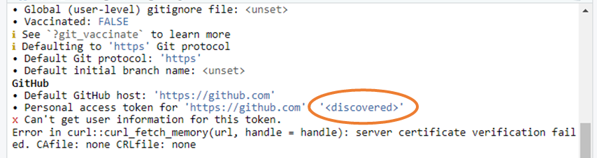

Now is a good time to restart RStudio to ensure everything is working as it should.

### Adding your GitHub repo to RStudio

We will now create a repository on GitHub to ensure we can access it in RStudio. Create a new repository in GitHub to test this out, by going to your GitHub homepage, then on the left under recent repositories, click the green button that says New.

[figure not shown]

Select your own account under Owner and give the repository a meaningful name, and add something meaningful in the description (otherwise when you have forgotten about this repo in a few years’ time, you won’t know if it’s safe to delete or not). Make sure you tick *Add a README File*.

[figure not shown]

Click on Create repository and your new repo will be created. Click on the green button that says Code, and copy the HTTPS that comes up. We need this to link the repo to RStudio.

[figure not shown]

Now go back to RStudio. In the menu at the top, go to *File > New project… > Version control > Git*. Now enter the HTTPS that you just copied, and select a folder where you want this repo to live, by changing *Create project as subdirectory of:*, then *Create project*.

[figure not shown]

### Option 2: Setting your username and PAT whenever you pull or push

If you didn’t use option 1 for setting your PAT, you will now be asked for your username and password. Enter your GitHub username, and paste the PAT into the password field.

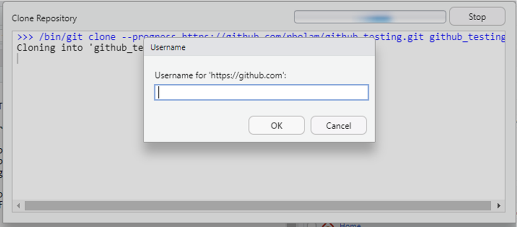

There might be a pop-up where you can save your username and password, so it will be autofilled for you. If there is no pop-up, you can set these in the browser.

In Edge, go to *Settings > Profiles > Passwords*. You can add a new password by going to the heading *Saved passwords* and clicking on *Add password*, then adding the URL of your RStudio on CDAP, your GitHub username, and the PAT for the password.

In Chrome, go to *Settings > Auto-fill*. Then under *Saved passwords*, click on *Add password*, and add your user information as above.

### Working with GitHub on RStudio

RStudio should restart with some changes. You should have a Git tab in one of the panes (usually top right or bottom right unless you have set it up differently). Under *Files*, you should see an RStudio project file with the name of your repo, as well as a README file.

[figure not shown]

Open the README file and add some more text, then *File > Save*, and click on the Git tab (saving changes is important, otherwise there won’t be anything coming up on your Git tab).

[figure not shown]

We will now do the following process. We will commit the changes – this means we are communicating that we have changed something, and what exactly we have changed. We will then pull from GitHub – that means we are getting the latest version of the code from GitHub (relevant if you work on the code with others). We will then push our changes to GitHub, so our latest changes will be on GitHub.

To commit, we find the README file in the Git tab. Here all our files are listed, and any we have changed will have a status of M. Click to the little box under Staged, then click on *Commit*.

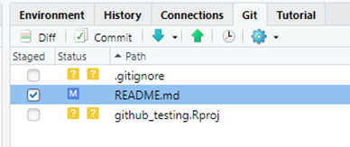

This will open a new window where you can review your changes, and add a commit message (make it meaningful), then click on *Commit*:

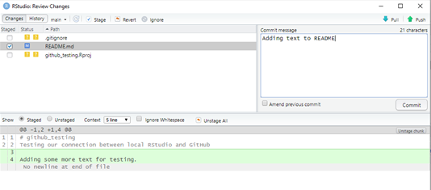

A little window should pop up to tell you what has been added (and hopefully without errors). Click Close and go back to the window where you can review your changes. The code at the bottom should have gone now as you have committed all changes. Now click *Pull*, which again should open a little window, then once it’s done close it.

[figure not shown]

Click on *Push*, again a little window should open, once the changes are done, click *Close*. This process should have updated your files on GitHub itself.

To see if your changes are on GitHub, go back to GitHub to the page of your new repo (you might have to reload the page). The text you added to your README file in RStudio should now be added:

[figure not shown]

If this has worked, then you are all set up to work with GitHub! You can delete the repository you created on GitHub and on CDAP.

From now on, you don’t need to repeat the steps for setting the PAT because they were all about getting you linked up (other than to update your PAT every 30 days).

To set up a new project, follow the steps outlined under **Adding your GitHub repo to RStudio**, then you can work in your code as normal and commit any changes you make on a regular basis.

You can also add existing projects to GitHub, and this is covered in the Happy Git with R book.